# Incognia Data Analysis

Hugo Daher

2022-03-01

[figure not shown]

# Incognia Data Analysis Report

## Introduction

Statistical analysis is a efficient way to get insights about any data, making anyone able to ask the right question. In addition, using the best technologies is crucial to get better results and faster. Therefore, this analysis used the powerful Language R to load and transform the dataset provided, creating significant visualizations with RStudio tool. Thus, this report has the result of statistical thinking that collected meaningful data to answer the right question with detailed analysis of patterns found in the data, making possible to draw conclusions that go beyond the observed data.

## Variables added to dataset schema

- event_hour: hour of the event day.
- event_date: event date (yyyy-mm-dd)
- device_age_category: variable device_age_days sliced in a category (“Day”,“Week”,“Month”,“Year”,“Year+”)
- dtfl_category: variable distance_to_frequent_location sliced in a category (“No Location”,“Frequent Location”,“Near FL”,“Far FL”)
- score_risk: variable that accumulates points whenever another variable indicates some risk
- risk_level: variable score_risk sliced in a category (“Low”,“Medium”,“High”)

## Dataset processing

### Loading dataset

```r
tb <- read.table("Dados/hugo_incognia_db_for_da_test.csv",
                    dec = ".",
                    sep = ",",
                    h = T,
                    fileEncoding = "windows-1252")
```

### Dataset general information

Dataset size is *444758* rows and *10* columns

> Compactly displaying the structure of dataset

```
## 'data.frame':    444758 obs. of  10 variables:
##  $ event_id                     : chr  "59bcca18-c726" "64c883df-2a7b" "527f8468-6a6a" "e062b8d9-6b5a" ...
##  $ event_timestamp              : num  1.63e+12 1.63e+12 1.63e+12 1.63e+12 1.63e+12 ...
##  $ account_id                   : int  1893155083 2050114867 422735906 1766209306 1860027669 256278006 1171219478 1498658439 1355561417 2086562840 ...
##  $ device                       : int  1801928094 1971517057 1956878295 1208828324 1768952722 1736326652 1079123361 1470762726 550479659 1021842367 ...
##  $ distance_to_frequent_location: num  1.85 36.26 226.41 0.11 1.73 ...
##  $ device_age_days              : int  527 184 92 366 278 524 265 181 1 505 ...
##  $ is_emulator                  : chr  "false" "false" "false" "false" ...
##  $ has_fake_location            : chr  "false" "false" "false" "false" ...
##  $ has_root_permissions         : chr  "false" "false" "false" "false" ...
##  $ app_is_from_official_store   : chr  "true" "true" "true" "true" ...
```

### Dataset transformation

> Removing id column, not necessary for analysis

```r
tb$event_id <- NULL
```

> converting variable to integer

```r
tb$distance_to_frequent_location <-
  as.integer(tb$distance_to_frequent_location)
```

> Converting miliseconds to timestamp

```r
tb$event_timestamp <- as.POSIXct(tb$event_timestamp / 1000,
                                 origin = "1970-01-01",
                                 tz = "UTC")
summary(tb$event_timestamp)
```

```
##                  Min.               1st Qu.                Median
## "2021-07-01 00:01:21" "2021-07-08 12:59:37" "2021-07-15 13:00:40"
##                  Mean               3rd Qu.                  Max.
## "2021-07-16 02:07:13" "2021-07-23 01:21:33" "2021-07-31 23:59:58"
```

> Creating variable Event Hour

```r
tb$event_hour <- format(tb$event_timestamp,"%H")
tb$event_hour <- as.numeric(tb$event_hour)
```

> Creating variable Event Date

```r
tb$event_date <- as.Date(tb$event_timestamp,format="%Y-%m-%d")
```

> Missing values

```r
#sapply(tb, function(x) sum(is.na(x)))
#Amelia::missmap(tb, main = "Missing Values")
```

There are 678 missing values. However, all missing values are in a location variable, which is crucial to determine risk because it’s a login attempt without location information. Solution was replace for -1 instead removing.

```r
tb <- tidyr::replace_na(tb, list(distance_to_frequent_location = -1))
```

> Creating a Device Age Category

```r
tb$device_age_category <- cut(tb$device_age_days,
            breaks = c(0,1,7,30,365,Inf),
            labels = c("Day","Week","Month","Year","Year+"), right = FALSE)
```

> Creating a Distance to frequent location Category

```r
tb$dtfl_category <- cut(tb$distance_to_frequent_location,
                              breaks = c(-1,0,1,10,Inf),
                              labels = c("No Location",
                                         "Frequent Location",
                                         "Near FL",
                                         "Far FL"), right = FALSE)
```

> Creating Risk Score variable

```r
tb$score_risk = 0
tb$score_risk <- tb$score_risk +
  ifelse(tb$event_hour>=0 & tb$event_hour<=5,1,0)
tb$score_risk <- tb$score_risk +
  ifelse(tb$dtfl_category=="No Location",3,0)
tb$score_risk <- tb$score_risk +
  ifelse(tb$dtfl_category=="Far FL",2,0)
tb$score_risk <- tb$score_risk +
  ifelse(tb$dtfl_category=="Near FL",1,0)
tb$score_risk <- tb$score_risk +
  ifelse(tb$device_age_category=="Day",3,0)
tb$score_risk <- tb$score_risk +
  ifelse(tb$is_emulator=="true",3,0)
tb$score_risk <- tb$score_risk +
  ifelse(tb$has_fake_location=="true",3,0)
tb$score_risk <- tb$score_risk +
  ifelse(tb$has_root_permissions=="true",3,0)
tb$score_risk <- tb$score_risk +
  ifelse(tb$app_is_from_official_store=="false",3,0)
```

> Creating Risk Level (category based on score)

```r
tb$risk_level <- cut(tb$score_risk,
                              breaks = c(0,1,3,Inf),
                              labels = c("Low","Medium","High"), right = FALSE)
```

> Creating a single column with all numeric variables and building a numeric only dataframe

```r
tb_pivot <- tidyr::pivot_longer(dplyr::select
                         (dplyr::select_if
                           (tb,is.numeric),-c("account_id", "device")),
                             cols = everything(), names_to = "numeric_var",
                             values_to = "values")

tb_num <- dplyr::select(dplyr::select_if
                        (tb,is.numeric),-c("account_id", "device"))
```

> Absolute and relative frequency

```r
# Absolute frequency
freq1 <- table(tb[c('is_emulator')])
freq2 <- table(tb[c('has_fake_location')])
freq3 <- table(tb[c('has_root_permissions')])
freq4 <- table(tb[c('app_is_from_official_store')])
freq5 <- table(tb[c('dtfl_category')])
freq6 <- table(tb[c('device_age_category')])
freq7 <- table(tb[c('event_hour')])
freq8 <- table(tb[c('risk_level')])

# Relative frequency
freq_rel1 <- round(prop.table(freq1),7)*100
freq_rel2 <- round(prop.table(freq2),7)*100
freq_rel3 <- round(prop.table(freq3),7)*100
freq_rel4 <- round(prop.table(freq4),7)*100
freq_rel5 <- round(prop.table(freq5),4)*100
freq_rel6 <- round(prop.table(freq6),4)*100
freq_rel7 <- round(prop.table(freq7),4)*100
freq_rel8 <- round(prop.table(freq8),4)*100
```

### Graphical representation of information and data

> Evaluating correlation between variables

```r
#GGally::ggpairs(tb_num, upper =
#                  list(continuous =
#                         GGally::wrap("cor", size = 3))) +
#  ggplot2::theme(
#    axis.text = ggplot2::element_text(size = 6),
#    axis.title = ggplot2::element_text(size = 6),
#    legend.background = ggplot2::element_rect(fill = "white"),
#    panel.grid.major = ggplot2::element_line(colour = NA),
#    panel.grid.minor = ggplot2::element_blank(),
#    panel.background = ggplot2::element_rect(fill = "grey95"))
```

> Heatmap analysis

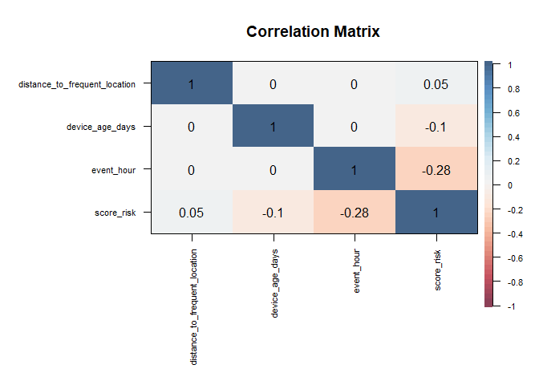

```r
psych::corPlot(tb_num, xlas=2, main="Correlation Matrix", scale=F,
        gr=colorRampPalette(c("#67001F", "#B2182B", "#D6604D", "#F4A582",
                              "#FDDBC7", "#eeeeee", "#D1E5F0", "#92C5DE",
                              "#4393C3", "#2166AC", "#053061")),
        cex=1,cex.axis=0.7)
```

> Barplot analysis

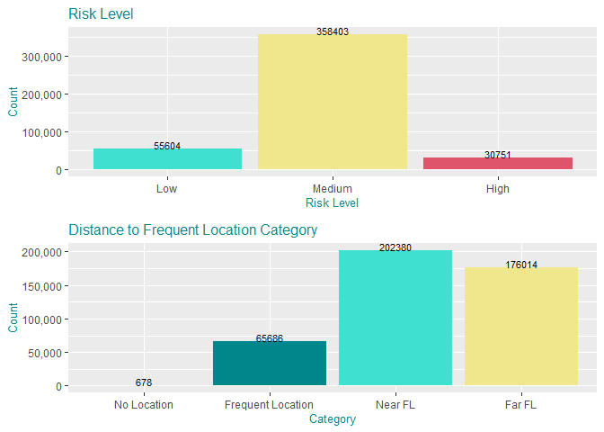

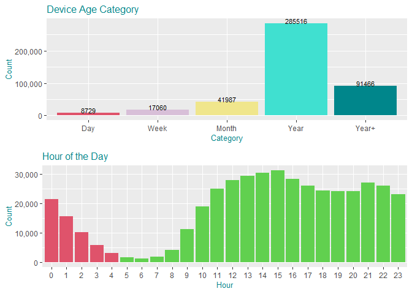

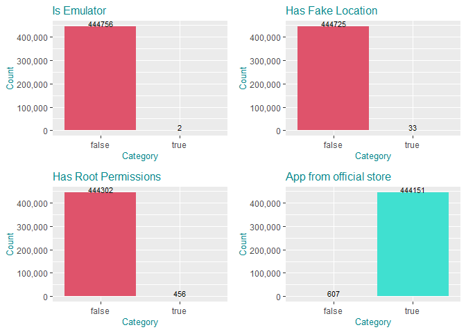

> Pie Chart

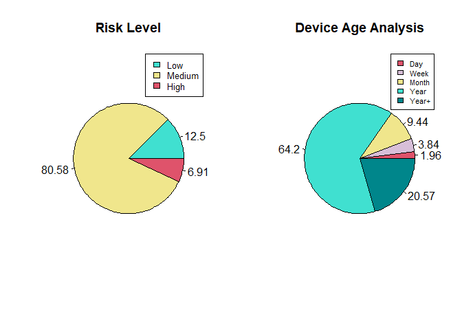

```r
# set the plotting area into a 1*3 array
par(mfrow=c(1,2))

pc <- pie(freq_rel8, labels = freq_rel8 ,
          main = "Risk Level",
          col = c("turquoise","khaki",2))
legend("topright", names(freq_rel8), cex = .8,
       fill = c("turquoise","khaki",2))

pc <- pie(freq_rel6, labels = freq_rel6 ,
          main = "Device Age Analysis",
          col = c(2,"thistle","khaki","turquoise","turquoise4"))
legend("topright", names(freq_rel6), cex = .7,
       fill = c(2,"thistle","khaki","turquoise","turquoise4"))
```

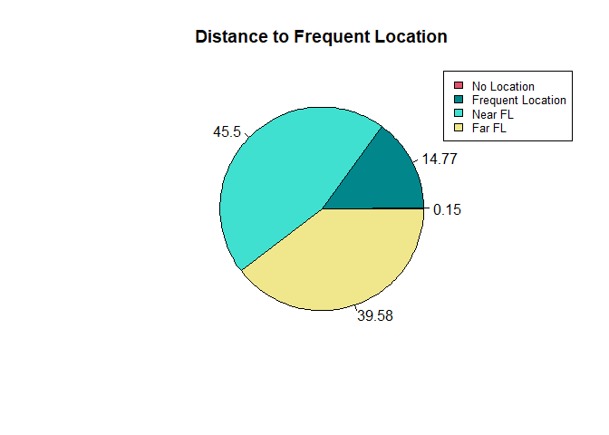

```r
par(mfrow=c(1,1))
pc <- pie(freq_rel5, labels = freq_rel5 ,
          main = "Distance to Frequent Location",
          col = c(2,"turquoise4","turquoise","khaki"))
legend("topright", names(freq_rel5), cex = .8,
       fill = c(2,"turquoise4","turquoise","khaki"),)
```

> Boxplot analysis

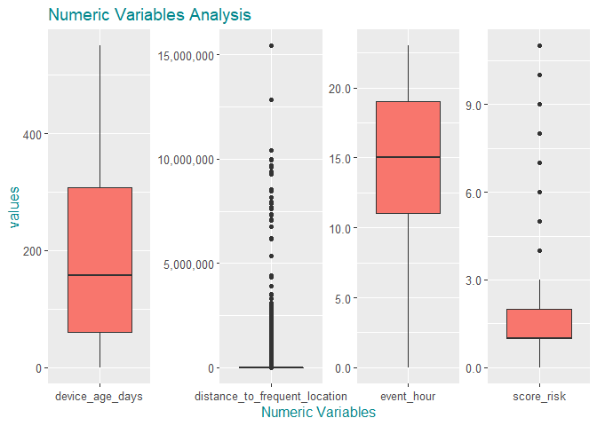

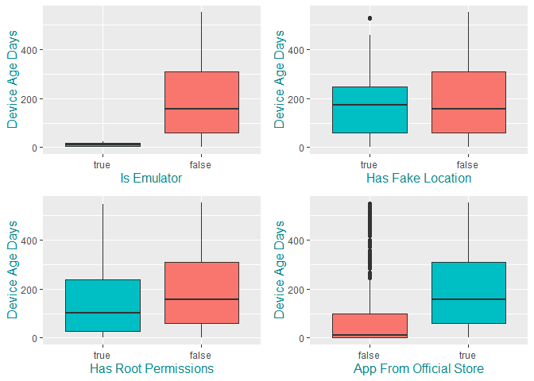

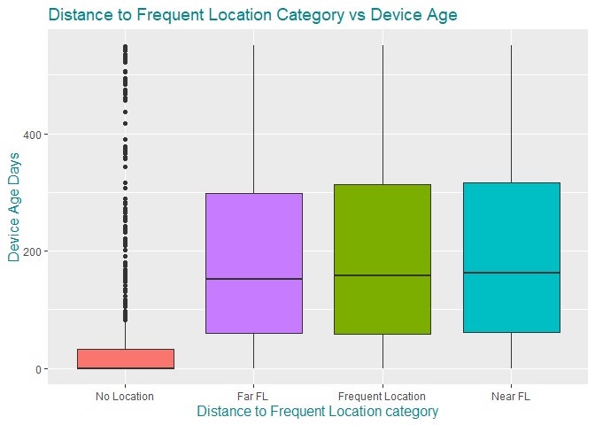

> Scatter Plot analysis

```r
# showing relation between two variables and a logical variable
#ggplot(data = tb, aes(y = distance_to_frequent_location,
#                      x = device_age_days)) +
#  geom_point(aes(color = risk_level), size = 2) +
#  ggtitle("Distance to frequent location vs Device Age") +
#  labs(y = "Distance to frequent location (Km)",
#       x = "Device Age (days)") +
#  theme(title = element_text(size = 12, color = "turquoise4"))
```

> Histogram of distribution

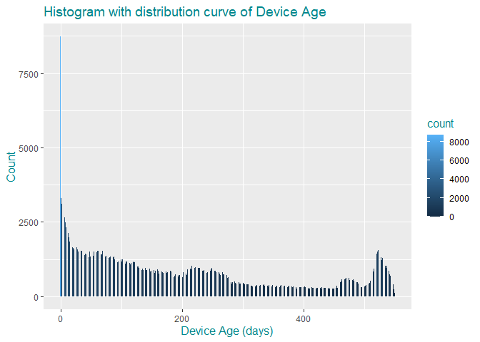

```r
# Device Age
df = data.frame(value = tb$device_age_days)
ggplot(df, aes(x=value)) +
  geom_histogram(binwidth = 0.5, aes(fill = ..count..)) +
  ggtitle("Histogram with distribution curve of Device Age") +
  labs(y = "Count",
       x = "Device Age (days)") +
  theme(title = element_text(size = 12, color = "turquoise4"))
```

> Area Chart analysis

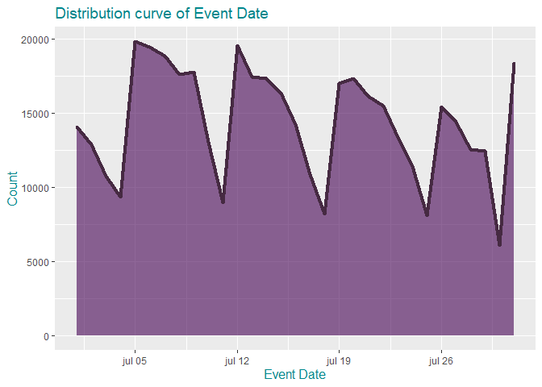

```r
# Event Date
temp <- dplyr::summarise(dplyr::group_by(tb,event_date),qtde = length(event_date))
df = data.frame(value = temp)
ggplot(df, aes(x=value.event_date,y=value.qtde, fill="#462a42")) +
  geom_area(alpha=0.6 , size=1.5, colour="#462a42") +
  viridis::scale_fill_viridis(discrete = T) +
  ggtitle("Distribution curve of Event Date") +
  labs(y = "Count",
       x = "Event Date") +
  theme(legend.position='none',
        title = element_text(size = 12, color = "turquoise4"))
```

### Analysis Coclusion

The dataset analysis found patterns related to the accounts and devices that indicate suspicious behavior, possibly associated with fraud. In this report, it is possible to understand how these patterns occur and how often. Moreover, with the patterns found, it was possible to create a variable that measures risk with a score points. The higher the score, the greater the risk. In addition, another variable was defined to categorize the risk level into **Low**, **Medium** and **High**. Therefore, Incognia will be able to improve the detection algorithm and with that, increase the efficiency in the communication with the financial client in order to avoid fraud.

## Machine Learning Model

### Objective

Create a machine learning model to predict whether a financial event is a fraud event based on patterns found in a dataset.

### Preparing data to the model

> Sample random rows in dataframe

Only 3000 rows were selected at random from the dataset. More than this value requires a higher computational level.

```r
df = data.frame(tb)
tb_ml <- df[sample(nrow(df), 3000), ]
```

> Suggesting a variable as a possible fraud

Risk Score greater than 3

```r
tb_ml$is_fraud <- ifelse(tb_ml$score_risk>=4,1,0)
```

> Converting some variables as factor

```r
tb_ml$is_fraud <- as.factor(tb_ml$is_fraud)
tb_ml$event_hour <- as.factor(tb_ml$event_hour)
tb_ml$score_risk <- as.factor(tb_ml$score_risk)
tb_ml$is_emulator <- as.factor(tb_ml$is_emulator)
tb_ml$has_fake_location <- as.factor(tb_ml$has_fake_location)
tb_ml$has_root_permissions <- as.factor(tb_ml$has_root_permissions)
tb_ml$app_is_from_official_store <- as.factor(tb_ml$app_is_from_official_store)
```

> Removing unnecesary variables

```r
tb_ml$account_id <- NULL
tb_ml$device <- NULL
tb_ml$event_timestamp <- NULL
tb_ml$event_date <- NULL
```

> Selecting 75% of rows according to variable IS_FRAUD

```r
library(caret)
# Set seed
set.seed(12345)
index <- createDataPartition(tb_ml$is_fraud, p = 0.75, list = FALSE)
dim(index)
```

```
## [1] 2250    1
```

> Setting training data as a subset

```r
data_training <- tb_ml[index,]
dim(data_training)
```

```
## [1] 2250   13
```

```r
table(data_training$is_fraud)
```

```
##
##    0    1
## 2214   36
```

> Percentages between classes

```r
prop.table(table(data_training$is_fraud))
```

```
##
##     0     1
## 0.984 0.016
```

### Model Results

To create a machine learning model it would be important to have a sample with descriptive information determining whether each event is a fraud event. With this information, it would be possible to create a prediction algorithm model to predict which future events will be a fraud event based on the training and testing model.